# Creativity-AI

Claudia Alvarez-Martin, Dan Dediu

2026-02-19

# Loading and preparing the data

The data for this study comes from different sources. First, we have the ratings provided by humam participants, which contain also their demographic information. To this information I will add more detailed data regarding their AReA score. Second, we have the ratings obtained from GPT-4O, both with and without human guidance. Finally, we also performed a “Turing test” where new participants were asked to identify the origin (human or GenAI) of the stimuli used in the rating task.

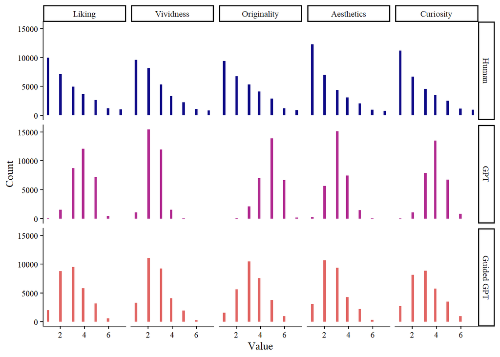

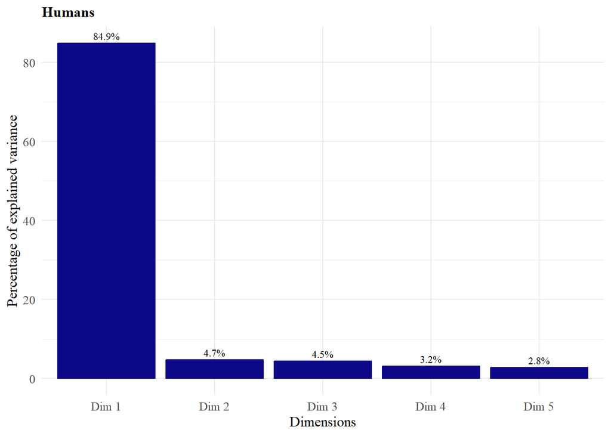

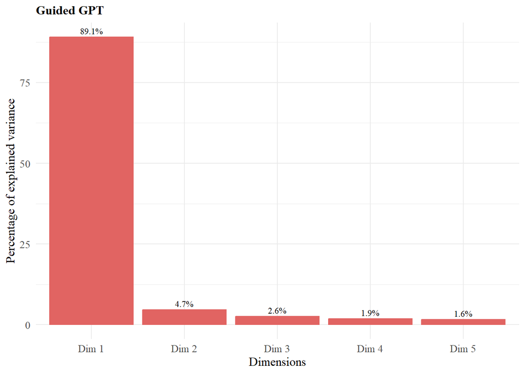

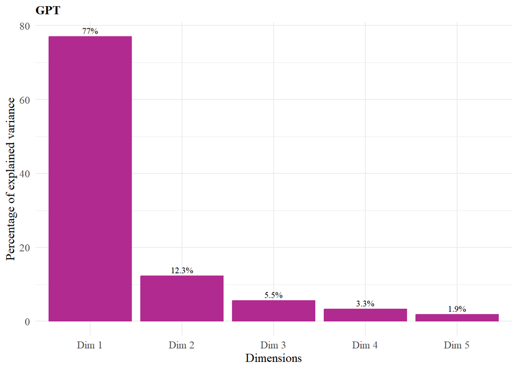

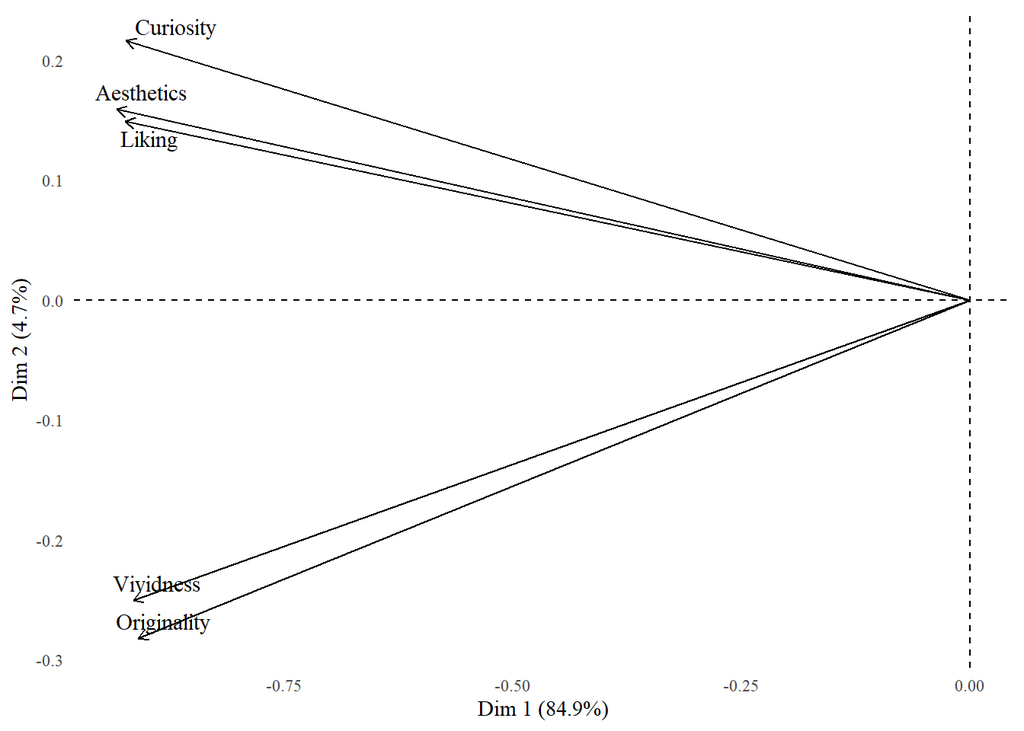

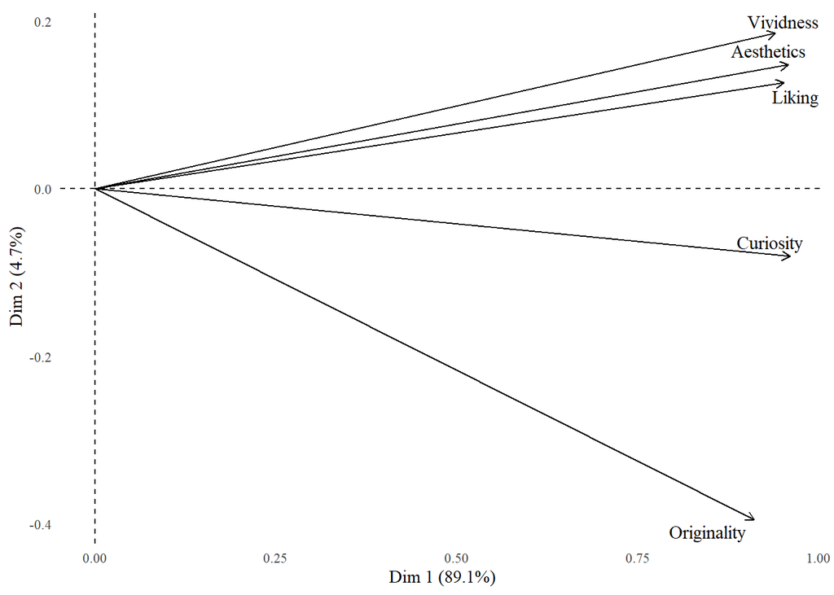

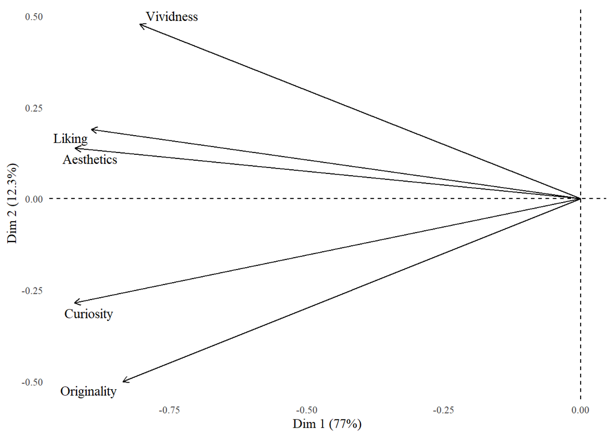

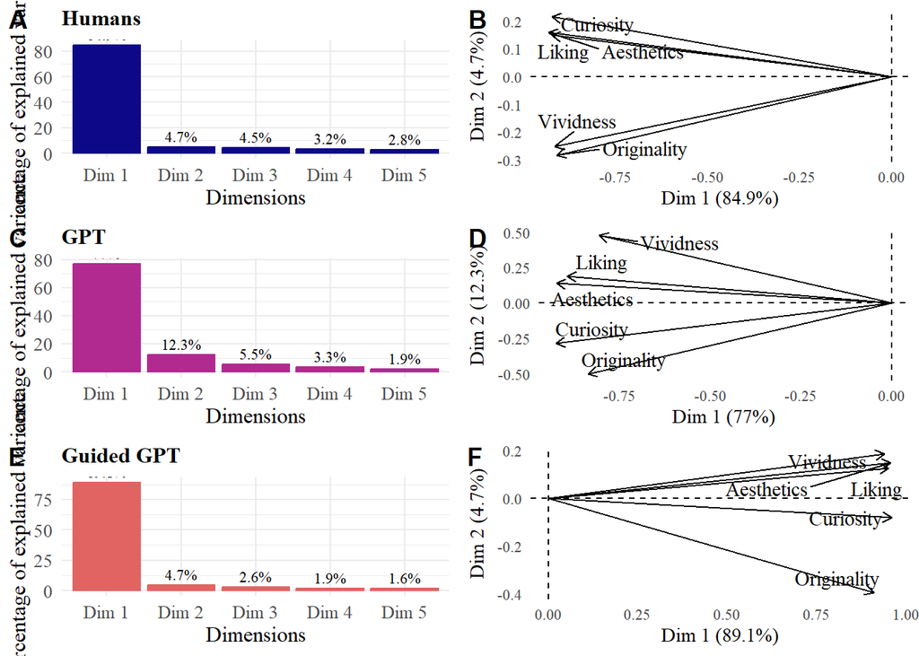

# 0- Response to the reviewer

## Comment 5

Original comment: **It would strengthen the study to include multiple human raters evaluating the same images, enabling assessment of inter-rater reliability and reproducibility.**

We will provide some measures to assess Inter-rater reliability and reproducibility.

The main problem is that most of the participants in the sample received completely different image datasets to rate, making it difficult to calculate inter-rater measures.

Here we can see the number of images in common for each pair of participants:

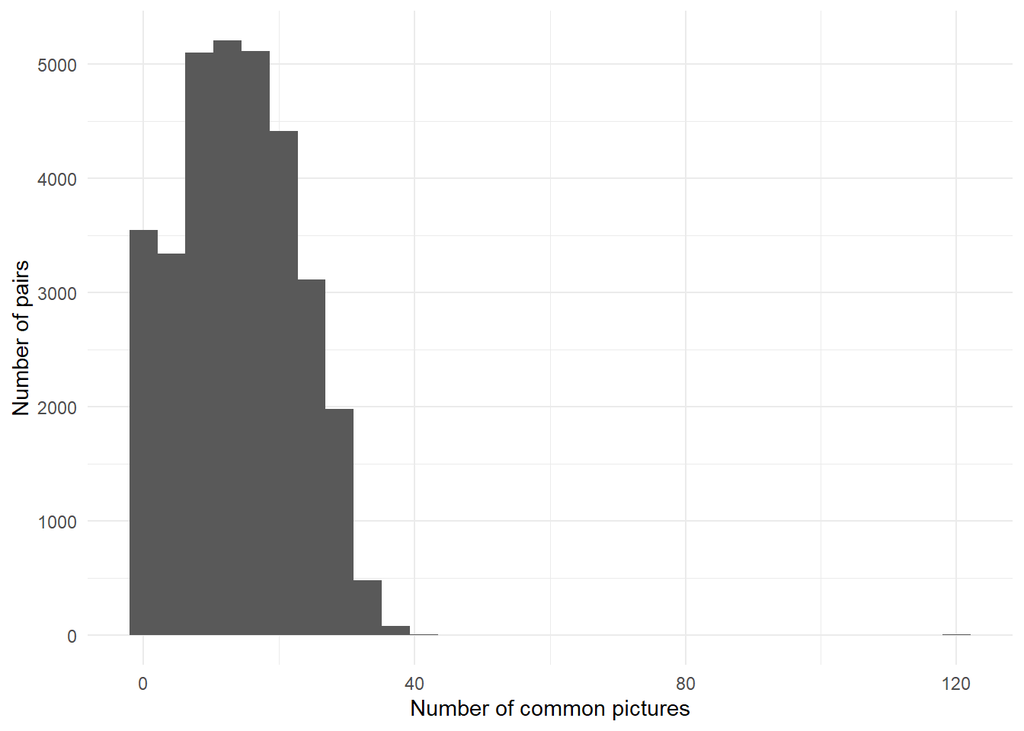

We see that the distribution shows some instances where participants rated the same 120 images. We plot again, removing those participants:

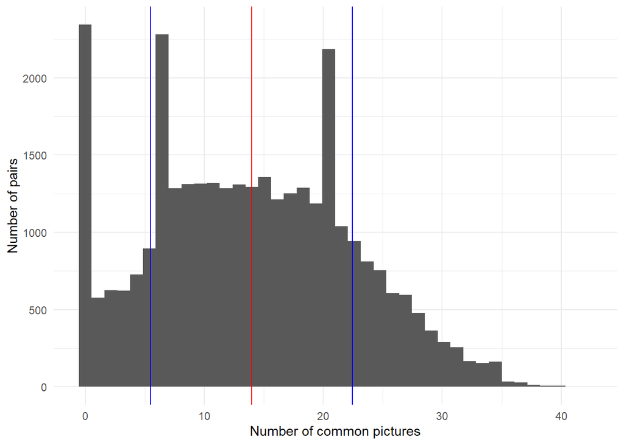

We can calculate, for the whole sample, Krippendorff’s alpha:

|  | Number of images | Number of raters | Alpha |
| --- | --- | --- | --- |
| liking | 1000 | 255 | 0.147498561672397 |
| vividness | 1000 | 255 | 0.192786490502244 |
| originality | 1000 | 255 | 0.12938274130992 |
| aesthetics | 1000 | 255 | 0.105290905929107 |
| curiosity | 1000 | 255 | 0.107711858658729 |

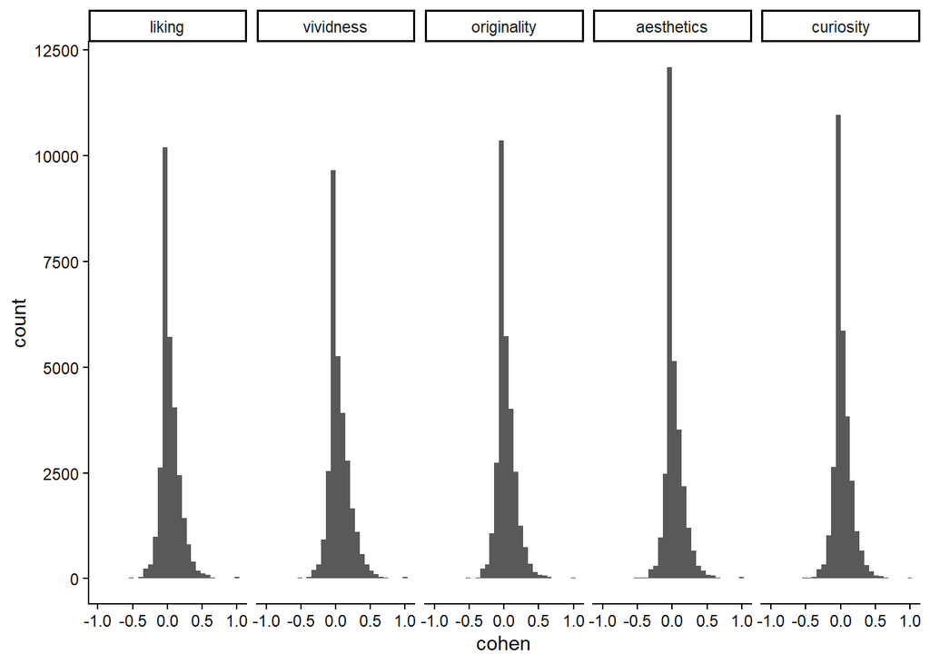

A more reliable way of assessing inter-rater reliability in a case like ours, with unequal raters per item and missingness, is using a mixed-effects model to perform variance decomposition. This allows us to estimate the percentage of variance in the ratings attributed to the effect of the raters and the images separately.

### Mixed effects model

```
## Liking:  0.1450077
## Vividness:  0.1826286
## Originality:  0.1284342
## Aesthetics:  0.1062472
## Curiosity:  0.1090813 NULL
```

Reliability is very low (between 10 and 18), meaning that the proportion of total rating variance that is attributable to real differences between images is low.

We can compute another measure of reliability using a split half technique, that will allow us to estimate how stable the image-level scores are. We will randomly split the ratings of each image into two halves and correlate the mean ratings of both subsets, repeating this operation in order to obtain a distribution and calculate a confidence interval.

```
##      [,1]          [,2]                    [,3]
## [1,] "Liking"      "0.706 (0.683 - 0.729)" "0.828 (0.812 - 0.843)"
## [2,] "Vividness"   "0.755 (0.736 - 0.774)" "0.86 (0.848 - 0.873)"
## [3,] "Originality" "0.667 (0.642 - 0.691)" "0.8 (0.782 - 0.817)"
## [4,] "Aesthetics"  "0.622 (0.595 - 0.65)"  "0.767 (0.746 - 0.788)"
## [5,] "Curiosity"   "0.625 (0.597 - 0.652)" "0.769 (0.748 - 0.789)"
```

In this case, the Spearman-Brown corrected reliability of all 5 subscales oscillates between 0.77 and 0.86, indicating good to strong reliability.

## Comment 6

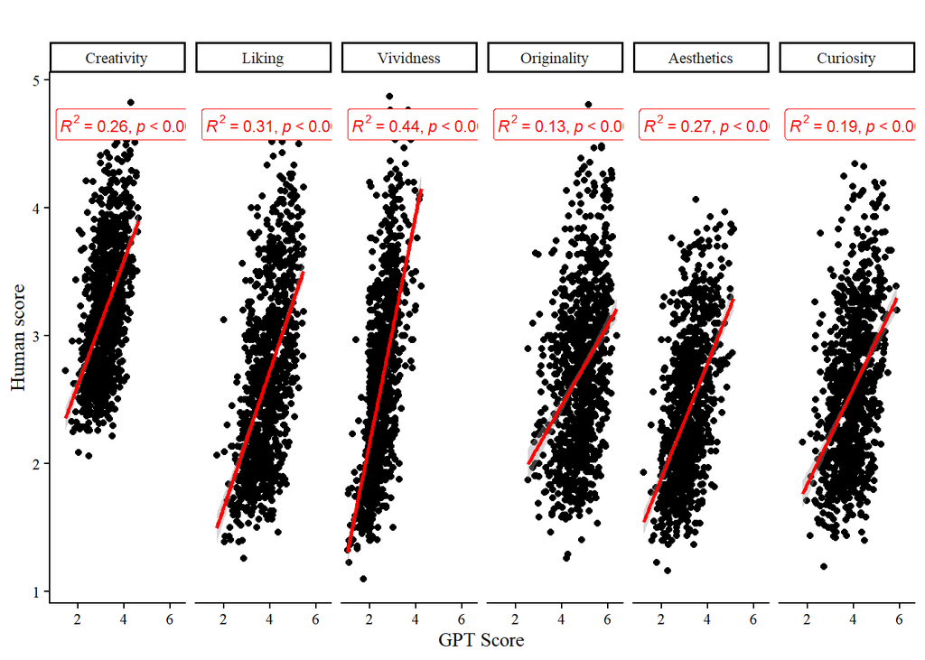

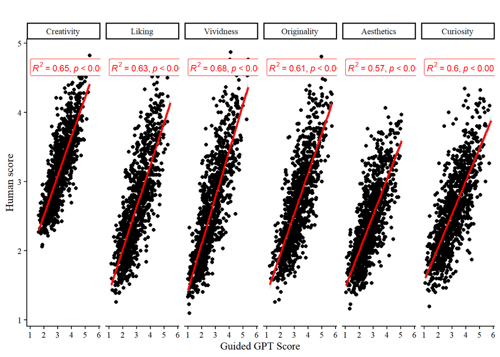

# Main analysis

## Effect of category on the ratings

### For human raters

```
## [1] 0.000 0.209 0.000
```

```
##      [,1]  [,2] [,3]
## [1,]    0 0.001    0
## [2,]    0 0.033    0
## [3,]    0 0.512    0
## [4,]    0 0.613    0
## [5,]    0 0.999    0
```

```
## $liking
## [1] "Chi(3)= 394.48, p.value = 0, Difference AIC = -388.48"
##
## $vividness
## [1] "Chi(3)= 363.93, p.value = 0, Difference AIC = -357.93"
##
## $originality
## [1] "Chi(3)= 332.3, p.value = 0, Difference AIC = -326.3"
##
## $aesthetics
## [1] "Chi(3)= 321.98, p.value = 0, Difference AIC = -315.98"
##
## $curiosity
## [1] "Chi(3)= 332.12, p.value = 0, Difference AIC = -326.12"
##
## $creativity
## [1] "Chi(3)= 375.92, p.value = 0, Difference AIC = -369.92"
```

```
##                                                     Estimate   Std. Error
##                              "Fixed effects"        ""         ""
##                              ""                     "Est/Beta" "SE"
##                              "Group"                ""         ""
## (Intercept)                  "Intercept"            "3.57"     "0.03"
## categoryNon Artists          "Non Artists"          "-0.35"    "0.04"
## categoryHuman Inspired GenAI "Human Inspired GenAI" "-0.43"    "0.04"
## categorySelf-Guided GenAI    "Self-Guided GenAI"    "-0.83"    "0.04"
##                              ""                     ""         ""
##                              "Random effects"       ""         ""
##                              ""                     ""         ""
##                              "Image (Intercept)"    ""         ""
##                              ""                     ""         ""
##                              "Model fit"            ""         ""
##                              ""                     ""         ""
##                              "R2"                   ""         ""
##
##                              ""              ""         ""
##                              "95% CI"        "t"        "p value"
##                              ""              ""         ""
## (Intercept)                  "3.52 - 3.62"   "138.14"   "0"
## categoryNon Artists          "-0.43 - -0.28" "-9.48"    "0"
## categoryHuman Inspired GenAI "-0.5 - -0.35"  "-11.1"    "0"
## categorySelf-Guided GenAI    "-0.9 - -0.75"  "-21.21"   "0"
##                              ""              ""         ""
##                              ""              ""         ""
##                              ""              "Variance" "S.D."
##                              ""              "0.142"    "0.377"
##                              ""              ""         ""
##                              ""              ""         ""
##                              ""              "Marginal" "Conditional"
##                              ""              "0.05"     "0.14"
```

```
## [1] "Chi(1)= 205.83, p.value = 0, Difference AIC = -203.83"
```

```
## $emmeans
##  category2 emmean     SE  df asymp.LCL asymp.UCL
##  Humans      3.40 0.0202 Inf      3.36      3.44
##  GenAI       2.95 0.0223 Inf      2.91      2.99
##
## Degrees-of-freedom method: asymptotic
## Confidence level used: 0.95
##
## $contrasts
##  contrast       estimate     SE  df z.ratio p.value
##  Humans - GenAI    0.454 0.0301 Inf  15.102  <.0001
##
## Degrees-of-freedom method: asymptotic
```

```
## Linear mixed model fit by REML. t-tests use Satterthwaite's method [
## lmerModLmerTest]
## Formula: creativity ~ categoryNonArtists + (1 | imageId)
##    Data: bd[bd$raterType == "Human", ]
##
## REML criterion at convergence: 99300.3
##
## Scaled residuals:
##     Min      1Q  Median      3Q     Max
## -2.1171 -0.7293 -0.2422  0.5653  3.7353
##
## Random effects:
##  Groups   Name        Variance Std.Dev.
##  imageId  (Intercept) 0.1425   0.3774
##  Residual             1.4348   1.1978
## Number of obs: 30600, groups:  imageId, 1000
##
## Fixed effects:
##                                         Estimate Std. Error        df t value
## (Intercept)                              3.22118    0.02673 996.30925 120.505
## categoryNonArtistsVisual Artists         0.35255    0.03720 996.57820   9.477
## categoryNonArtistsHuman Inspired GenAI  -0.07627    0.03922 996.47684  -1.945
## categoryNonArtistsSelf-Guided GenAI     -0.47506    0.03959 996.48214 -11.999
##                                        Pr(>|t|)
## (Intercept)                              <2e-16 ***
## categoryNonArtistsVisual Artists         <2e-16 ***
## categoryNonArtistsHuman Inspired GenAI   0.0521 .
## categoryNonArtistsSelf-Guided GenAI      <2e-16 ***
## ---
## Signif. codes:  0 '***' 0.001 '**' 0.01 '*' 0.05 '.' 0.1 ' ' 1
##
## Correlation of Fixed Effects:
##             (Intr) ctNAVA cNAHIG
## ctgryNnArVA -0.719
## ctgrNAHIGAI -0.682  0.490
## ctgNAS-GGAI -0.675  0.485  0.460
```

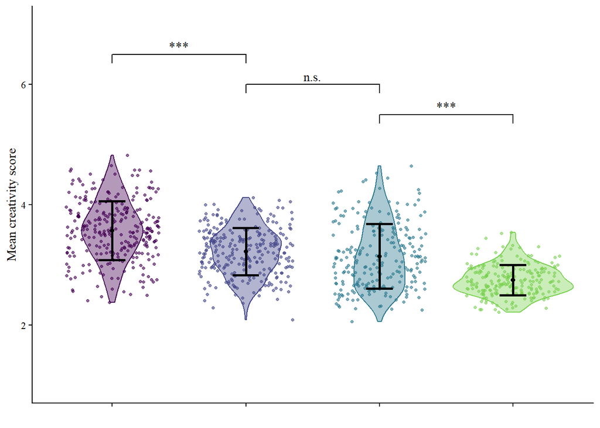

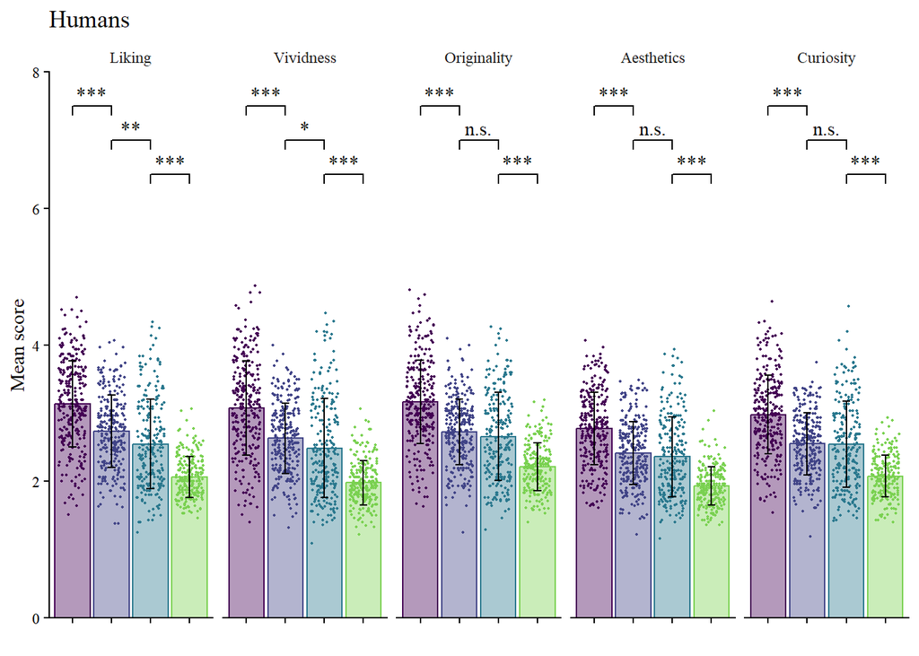

### For GPT ratings

```
## [1] 0.992 0.085 0.000
```

```
##       [,1]  [,2] [,3]
## [1,] 1.000 0.992    0
## [2,] 0.912 0.097    0
## [3,] 0.992 0.000    0
## [4,] 0.818 0.024    0
## [5,] 0.999 0.003    0
```

```
## $liking
## [1] "Chi(3)= 83.27, p.value = 0, Difference AIC = -77.27"
##
## $vividness
## [1] "Chi(3)= 90.32, p.value = 0, Difference AIC = -84.32"
##
## $originality
## [1] "Chi(3)= 29.18, p.value = 0, Difference AIC = -23.18"
##
## $aesthetics
## [1] "Chi(3)= 41.73, p.value = 0, Difference AIC = -35.73"
##
## $curiosity
## [1] "Chi(3)= 29.39, p.value = 0, Difference AIC = -23.39"
##
## $creativity
## [1] "Chi(3)= 41.87, p.value = 0, Difference AIC = -35.87"
```

```
## [1] "Chi(1)= 2.08, p.value = 0.15, Difference AIC = -0.08"
```

```
## $emmeans
##  category2 emmean     SE  df asymp.LCL asymp.UCL
##  Humans      3.22 0.0235 Inf      3.17      3.27
##  GenAI       3.17 0.0258 Inf      3.12      3.22
##
## Degrees-of-freedom method: asymptotic
## Confidence level used: 0.95
##
## $contrasts
##  contrast       estimate     SE  df z.ratio p.value
##  Humans - GenAI   0.0503 0.0349 Inf   1.440  0.1498
##
## Degrees-of-freedom method: asymptotic
```

```
##                                    Estimate   Std. Error
##                "Fixed effects"     ""         ""         ""
##                ""                  "Est/Beta" "SE"       "95% CI"
##                "Group"             ""         ""         ""
## (Intercept)    "(Intercept)"       "3.22"     "0.02"     "3.17 - 3.27"
## category2GenAI "category2GenAI"    "-0.05"    "0.03"     "-0.12 - 0.02"
##                ""                  ""         ""         ""
##                "Random effects"    ""         ""         ""
##                ""                  ""         ""         ""
##                "Image (Intercept)" ""         ""         ""
##                ""                  ""         ""         ""
##                "Model fit"         ""         ""         ""
##                ""                  ""         ""         ""
##                "R2"                ""         ""         ""
##
##                ""         ""
##                "t"        "p value"
##                ""         ""
## (Intercept)    "137.28"   "0"
## category2GenAI "-1.44"    "0.15"
##                ""         ""
##                ""         ""
##                "Variance" "S.D."
##                "0.297"    "0.545"
##                ""         ""
##                ""         ""
##                "Marginal" "Conditional"
##                "0"        "0.7"
```

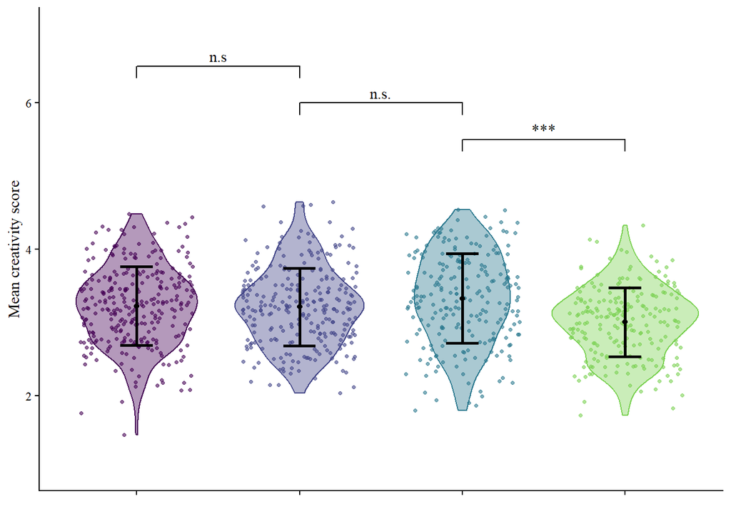

[figure not shown]

### For Guided GPT ratings

```
## [1] 0 0 0
```

```
##       [,1] [,2] [,3]
## [1,] 0.000    0    0
## [2,] 0.000    0    0
## [3,] 0.000    0    0
## [4,] 0.001    0    0
## [5,] 0.000    0    0
```

```
## $liking
## [1] "Chi(3)= 419.94, p.value = 0, Difference AIC = -413.94"
##
## $vividness
## [1] "Chi(3)= 324.64, p.value = 0, Difference AIC = -318.64"
##
## $originality
## [1] "Chi(3)= 292.35, p.value = 0, Difference AIC = -286.35"
##
## $aesthetics
## [1] "Chi(3)= 289.7, p.value = 0, Difference AIC = -283.7"
##
## $curiosity
## [1] "Chi(3)= 359.01, p.value = 0, Difference AIC = -353.01"
##
## $creativity
## [1] "Chi(3)= 355.23, p.value = 0, Difference AIC = -349.23"
```

[figure not shown]

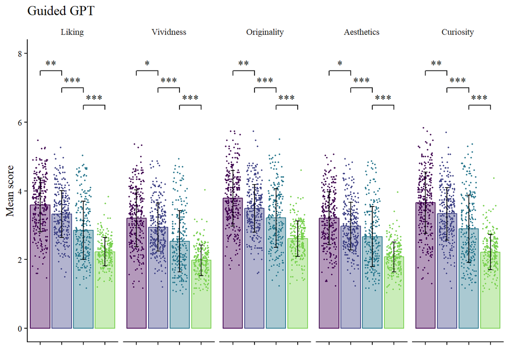

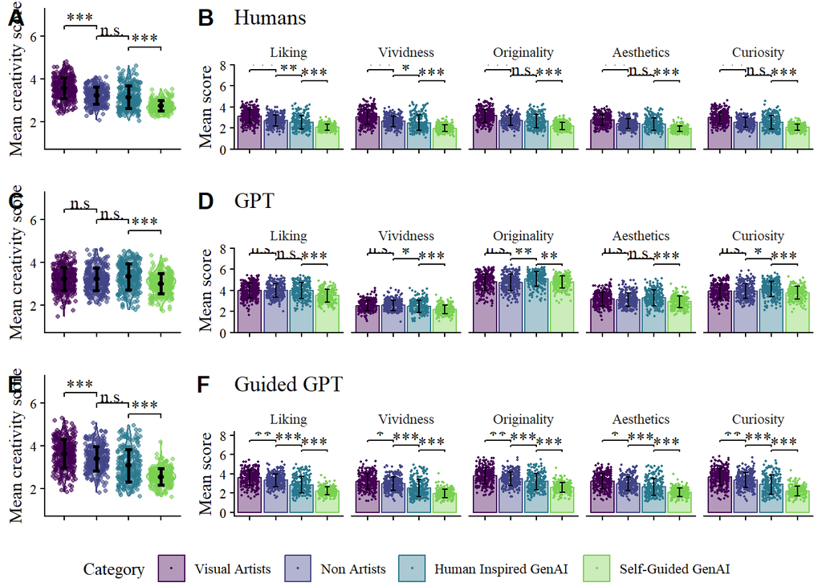

## Differences in ratings between rater types

```
## Linear mixed model fit by REML. t-tests use Satterthwaite's method [
## lmerModLmerTest]
## Formula: creativity ~ raterType * category + (1 | imageId)
##    Data: bd
##
## REML criterion at convergence: 228322.9
##
## Scaled residuals:
##     Min      1Q  Median      3Q     Max
## -3.4192 -0.6068 -0.0854  0.4598  5.8819
##
## Random effects:
##  Groups   Name        Variance Std.Dev.
##  imageId  (Intercept) 0.2136   0.4621
##  Residual             0.7011   0.8373
## Number of obs: 90587, groups:  imageId, 1000
##
## Fixed effects:
##                                                   Estimate Std. Error
## (Intercept)                                      3.575e+00  2.891e-02
## raterTypeGPT                                    -3.479e-01  1.279e-02
## raterTypeGuidedGPT                               5.593e-02  1.279e-02
## categoryNon Artists                             -3.535e-01  4.157e-02
## categoryHuman Inspired GenAI                    -4.299e-01  4.317e-02
## categorySelf-Guided GenAI                       -8.284e-01  4.360e-02
## raterTypeGPT:categoryNon Artists                 3.407e-01  1.839e-02
## raterTypeGuidedGPT:categoryNon Artists           1.196e-01  1.839e-02
## raterTypeGPT:categoryHuman Inspired GenAI        5.316e-01  1.910e-02
## raterTypeGuidedGPT:categoryHuman Inspired GenAI -1.339e-01  1.910e-02
## raterTypeGPT:categorySelf-Guided GenAI           6.080e-01  1.929e-02
## raterTypeGuidedGPT:categorySelf-Guided GenAI    -2.588e-01  1.930e-02
##                                                         df t value Pr(>|t|)
## (Intercept)                                      1.137e+03 123.654  < 2e-16 ***
## raterTypeGPT                                     8.958e+04 -27.200  < 2e-16 ***
## raterTypeGuidedGPT                               8.958e+04   4.373 1.23e-05 ***
## categoryNon Artists                              1.137e+03  -8.504  < 2e-16 ***
## categoryHuman Inspired GenAI                     1.137e+03  -9.958  < 2e-16 ***
## categorySelf-Guided GenAI                        1.137e+03 -19.000  < 2e-16 ***
## raterTypeGPT:categoryNon Artists                 8.958e+04  18.524  < 2e-16 ***
## raterTypeGuidedGPT:categoryNon Artists           8.958e+04   6.504 7.86e-11 ***
```

[output cut: 17 more lines]

```
## rTGGPT:HIGA  0.147 -0.332 -0.670 -0.102 -0.219 -0.097  0.231  0.466  0.495
## rTGPT:S-GGA  0.145 -0.663 -0.328 -0.101 -0.097 -0.219  0.461  0.228  0.444
## rTGGPT:S-GG  0.145 -0.328 -0.663 -0.101 -0.097 -0.219  0.228  0.461  0.220
##             rTGGIG rTGPTG
## raterTypGPT
## rtrTypGdGPT
## ctgryNnArts
## ctgryHIGnAI
## ctgryS-GGAI
## rtrTyGPT:NA
## rtrTGGPT:NA
## rTGPT:HIGAI
## rTGGPT:HIGA
## rTGPT:S-GGA  0.220
## rTGGPT:S-GG  0.444  0.495
```

```
## $emmeans
## category = Visual Artists:
##  raterType emmean     SE  df asymp.LCL asymp.UCL
##  Human       3.57 0.0289 Inf      3.52      3.63
##  GPT         3.23 0.0289 Inf      3.17      3.28
##  GuidedGPT   3.63 0.0289 Inf      3.57      3.69
##
## category = Non Artists:
##  raterType emmean     SE  df asymp.LCL asymp.UCL
##  Human       3.22 0.0299 Inf      3.16      3.28
##  GPT         3.21 0.0299 Inf      3.16      3.27
##  GuidedGPT   3.40 0.0299 Inf      3.34      3.46
##
## category = Human Inspired GenAI:
##  raterType emmean     SE  df asymp.LCL asymp.UCL
##  Human       3.14 0.0321 Inf      3.08      3.21
##  GPT         3.33 0.0321 Inf      3.27      3.39
##  GuidedGPT   3.07 0.0321 Inf      3.00      3.13
##
## category = Self-Guided GenAI:
##  raterType emmean     SE  df asymp.LCL asymp.UCL
##  Human       2.75 0.0326 Inf      2.68      2.81
##  GPT         3.01 0.0327 Inf      2.94      3.07
##  GuidedGPT   2.54 0.0327 Inf      2.48      2.61
##
## Degrees-of-freedom method: asymptotic
## Confidence level used: 0.95
##
## $contrasts
## category = Visual Artists:
##  contrast          estimate     SE  df z.ratio p.value
##  Human - GPT        0.34790 0.0128 Inf  27.200  <.0001
##  Human - GuidedGPT -0.05593 0.0128 Inf  -4.373  <.0001
##  GPT - GuidedGPT   -0.40383 0.0129 Inf -31.423  <.0001
##
## category = Non Artists:
##  contrast          estimate     SE  df z.ratio p.value
##  Human - GPT        0.00724 0.0132 Inf   0.548  0.8477
##  Human - GuidedGPT -0.17555 0.0132 Inf -13.285  <.0001
##  GPT - GuidedGPT   -0.18278 0.0133 Inf -13.763  <.0001
##
## category = Human Inspired GenAI:
##  contrast          estimate     SE  df z.ratio p.value
##  Human - GPT       -0.18375 0.0142 Inf -12.953  <.0001
##  Human - GuidedGPT  0.07797 0.0142 Inf   5.496  <.0001
##  GPT - GuidedGPT    0.26172 0.0143 Inf  18.359  <.0001
##
## category = Self-Guided GenAI:
##  contrast          estimate     SE  df z.ratio p.value
##  Human - GPT       -0.26010 0.0144 Inf -18.013  <.0001
##  Human - GuidedGPT  0.20287 0.0144 Inf  14.042  <.0001
##  GPT - GuidedGPT    0.46296 0.0145 Inf  31.891  <.0001
##
## Degrees-of-freedom method: asymptotic
## P value adjustment: tukey method for comparing a family of 3 estimates
```

```
## [1] "Chi(9)= 3001.24, p.value = 0, Difference AIC = -2983.24"
```

```
## [1] "Chi(8)= 2741.23, p.value = 0, Difference AIC = -2725.23"
```

```
## [1] "Chi(6)= 2741.23, p.value = 0, Difference AIC = -2729.23"
```

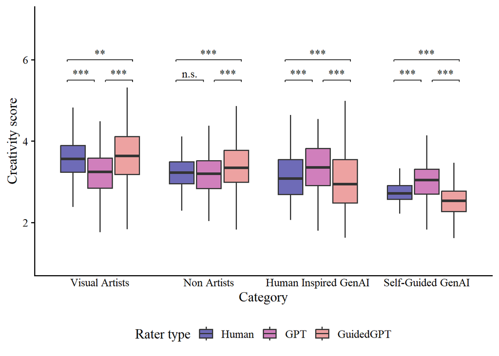

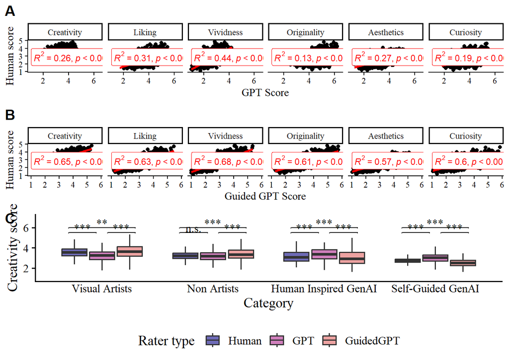

## Effect of AReA on ratings

```
## $emmeans
##  areaGroup emmean     SE  df asymp.LCL asymp.UCL
##  High        3.46 0.0154 Inf      3.43      3.49
##  Low         2.89 0.0154 Inf      2.86      2.92
##
## Results are averaged over the levels of: category
## Degrees-of-freedom method: asymptotic
## Confidence level used: 0.95
##
## $contrasts
##  contrast   estimate     SE  df z.ratio p.value
##  High - Low    0.565 0.0135 Inf  41.792  <.0001
##
## Results are averaged over the levels of: category
## Degrees-of-freedom method: asymptotic
```

```
## [1] "Chi(6)= 379.55, p.value = 0, Difference AIC = -367.55"
```

```
## [1] "Chi(4)= 1721.23, p.value = 0, Difference AIC = -1713.23"
```

```
## [1] "Chi(3)= 1.51, p.value = 0.68, Difference AIC = 4.49"
```

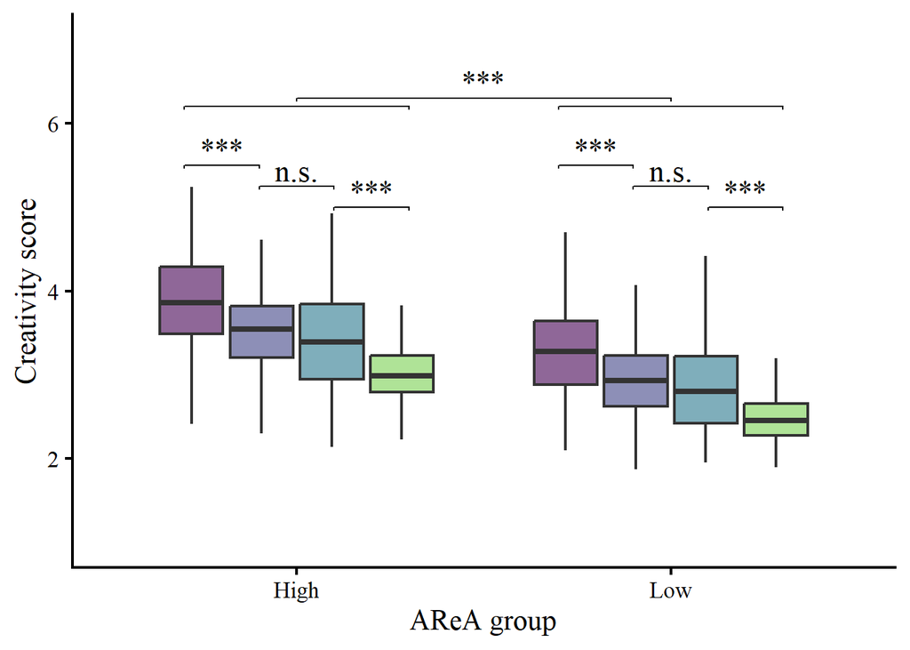

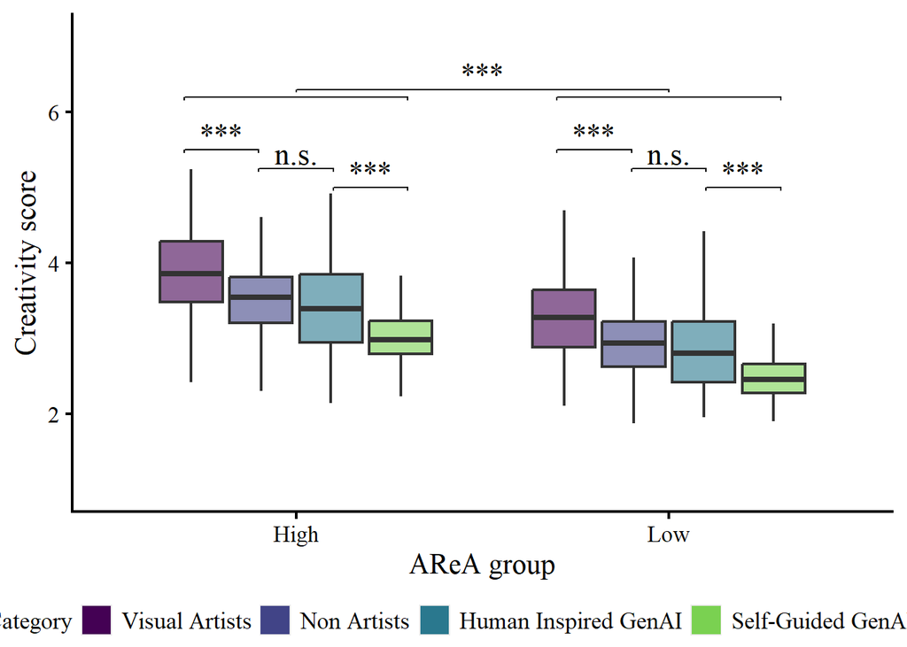